# Analyse de variance et régression multiple (1)

Exercice d’application sur les DPE de Rouen

Author

Claude Grasland

Published

July 9, 2027

```r
library(knitr)
library(dplyr)
library(beanplot)
library(sf)
library(mapsf)
library(RColorBrewer)
```

## (A) Préparation des données

### Chargement du fichier

On charge un fichier stocké au format interne de R appelé *dpe.RDS*. Il s’agit d’un fichier de type sf comportant la géométrie des localisationsd d’une zone d’étude centrée sur Rouen

```r
dpe<-readRDS("data/dpe.RDS")
class(dpe)
```

```
[1] "sf"         "data.frame"
```

```r
kable(head(dpe))
```

| id | zone | com_code | com_name | iris_code | iris_name | quart_code | quart_name | idcar_200m | dat | per | typ | dpe | sup | con_tot | con_m2 | ene | geometry |
| --- | --- | --- | --- | --- | --- | --- | --- | --- | --- | --- | --- | --- | --- | --- | --- | --- | --- |
| 2276E0601625K | Zone | 76108 | Bois-Guillaume | 761080104 | La Bretèque | 7610801 | Bois-Guillaume | CRS3035RES200mN2967800E3677800 | 1960 | 1948-1974 | appartement | C | 65.0 | 9607.2 | 147.8 | Gaz naturel | POINT (562548.4 6932080) |
| 2276E0604660D | Zone | 76540 | Rouen | 765400104 | Vieux Marché Sud Saint-Éloi | 7654001 | Centre Rive Droite Ouest | CRS3035RES200mN2964800E3676200 | 1900 | avant 1948 | appartement | D | 56.7 | 13449.7 | 237.2 | Gaz naturel | POINT (561141 6928855) |
| 2276E0812571S | Zone | 76498 | Le Petit-Quevilly | 764980110 | Les Bruyères | 7649801 | Le Petit-Quevilly | CRS3035RES200mN2961600E3674000 | 1970 | 1948-1974 | appartement | E | 54.5 | 15687.2 | 288.1 | Électricité | POINT (559409.1 6925510) |
| 2276E0037900R | Zone | 76540 | Rouen | 765400601 | Saint-Hilaire | 7654006 | Quartiers Est | CRS3035RES200mN2964200E3678800 | 1948 | 1948-1974 | appartement | F | 90.6 | 29722.1 | 328.0 | Gaz naturel | POINT (563744.8 6928629) |
| 2276E0041369C | Zone | 76540 | Rouen | 765400106 | Beauvoisine | 7654001 | Centre Rive Droite Ouest | CRS3035RES200mN2964800E3677200 | 1949 | avant 1948 | maison | D | 70.0 | 12936.9 | 192.0 | Électricité | POINT (562180.7 6929056) |
| 2276E1163399C | Zone | 76474 | Notre-Dame-de-Bondeville | 764740104 | Les Coteaux-Les Longs Vallons | 7647401 | Notre-Dame-de-Bondeville | CRS3035RES200mN2968600E3674600 | NA | 1948-1974 | appartement | F | 27.0 | 9698.8 | 359.0 | Électricité | POINT (559164.4 6932453) |

On peut afficher la carte des dpe en la superposant sur un fonds de carte des iris

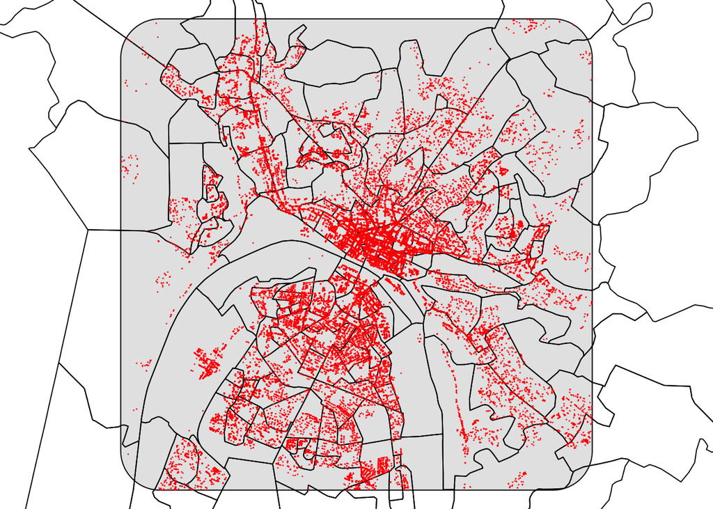

```r
mapiris <- readRDS("data/mapiris.RDS")
zone <- readRDS("data/zone.RDS")
buffer <- readRDS("data/buffer.RDS")

par(mar=c(0,0,0,0))
plot(buffer$geom, col="gray90")
plot(zone$geom, add=T, col="lightyellow")
plot(mapiris$geom, add=T, col=NA, border="black")
plot(dpe$geometry, add=T,col="red", pch=20, cex=0.1)
```

### Contenu du fichier

Ce dossier contient les données DPE de la zone d’étude Le nom des variables a été changé par rapport au fichier original, donc on charge le tableau des métadonnées et on l’affiche

```r
dpe_meta<-readRDS("data/dpe_meta.RDS")
kable(dpe_meta)
```

| var | label |
| --- | --- |
| id | Identififiant DPE |
| zone | Zone d’étude ou buffer |
| com_code | Code INSEE de la commune |
| com_name | Nom de la commune |
| iris_code | Code INSEE de l’IRIS |
| iris_name | Nom de l’IRIS |
| quart_code | Code INSEE du quartier |
| quart_name | Nom du quartier |
| idcar_200m | Code INSEE du carreau de 200m |
| dat | Ancienneté du bâtiment |
| per | Periode de construction |
| typ | Type de bâtiment |
| dpe | Classe DPE (A..G) |
| sup | Surface habitable du logement |
| con_tot | Consommation totale d’énergie primaire |
| con_m2 | Consommation totale d’énergie primaire par m2 |
| ene | Energie principale |
| geometry | Coordonnées géographiques |

### Sélection des unités et recodage des variables

On élimine les coordonnées géographiques, on sélectionne la commune de Rouen et on retient un nombre limité de variables

```r
## Sélectionne les lignes et colonnes
don <- dpe %>% st_drop_geometry(dpe) %>%
               filter(substr(iris_code,1,5) == 76540,           # Choisit Rouen
                      typ != "immeuble",   # Retire les appartements
                      sup <300,            # Retire les logements > 300 m2
                      dat> 1925) %>%       # Retire les logements de plus de 100 ans
                 mutate(iris_code = as.character(iris_code),
                        iris_name = as.character(iris_name),
                       typ = as.factor(as.character(typ)), # Recode le type sans les immeubles
                      anc = 2025-dat) %>%
               select(iris_code,
                      iris_name,
                      dpe,
                      con_tot,
                      sup,
                      con_m2,
                      typ,
                      ene,
                      anc,
                      per)


## Elimine les données incomplètes
don <- don[complete.cases(don),]

## Ajuste le fonds des iris
mapiris <- mapiris %>% filter(substr(iris_code,1,5)== 76540)
```

### Résumé de l’ensemble du tableau

```r
summary(don)
```

```
  iris_code          iris_name         dpe         con_tot
 Length:22960       Length:22960       A:   7   Min.   :  986.9
 Class :character   Class :character   B: 470   1st Qu.: 6279.5
 Mode  :character   Mode  :character   C:7861   Median : 9347.6
                                       D:7217   Mean   :10884.9
                                       E:4879   3rd Qu.:13536.4
                                       F:1567   Max.   :97363.6
                                       G: 959
      sup             con_m2                typ
 Min.   :  5.60   Min.   :  36.8   appartement:21727
 1st Qu.: 32.60   1st Qu.: 142.6   maison     : 1233
 Median : 51.10   Median : 207.0
 Mean   : 53.22   Mean   : 223.6
 3rd Qu.: 68.90   3rd Qu.: 271.5
 Max.   :279.00   Max.   :1603.0

                         ene            anc                per
 Gaz naturel               :9577   Min.   : 1.00   1948-1974 :8544
 Électricité               :9036   1st Qu.:23.00   avant 1948:3487
 Réseau de Chauffage urbain:4093   Median :52.00   2013-2021 :2755
 Fioul domestique          : 226   Mean   :48.48   1989-2000 :2506
 GPL                       :  15   3rd Qu.:76.00   2006-2012 :2150
 Bois – Bûches             :   8   Max.   :99.00   2001-2005 :1141
 (Other)                   :   5                   (Other)   :2377
```

## (B) ANALYSE DE LA VARIABLE DEPENDANTE

On s’intéresse à la variable con_m2 qui est la consommation finale en Kwh/m2/an. Avant de l’utilise on doit s’assurer que sa distribution est approximativement gaussienne.

### La distribution de con_m2 est-elle normale ?

On fait un histogramme :

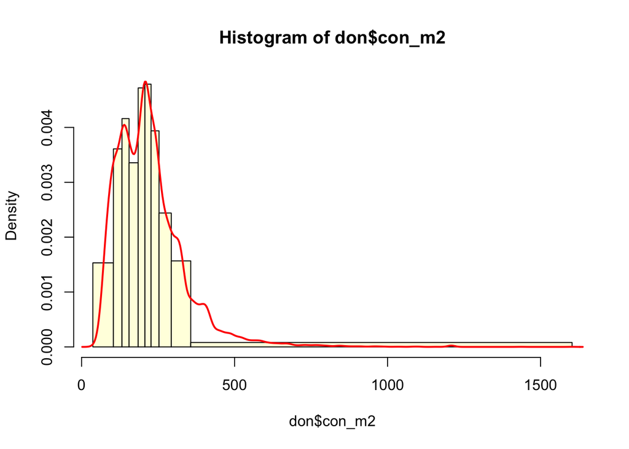

```r
hist(don$con_m2,
     breaks = quantile(don$con_m2,probs = seq(0,1,0.1)),
     col="lightyellow",
     probability = TRUE)
lines(density(don$con_m2),
      col="red",
      lwd=2)
```

La distribution n’est claiement pas symétrique.

Que nous apprend la boxplot ?

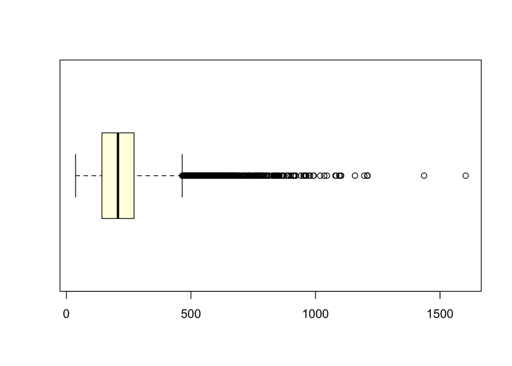

```r
boxplot(don$con_m2, col="lightyellow",horizontal = T)
```

Il y a un grand nombe de valeurs exceptionnelles à droite

### Solution n°1 : Retirer les valeurs exceptionnelles

La distribution n’est clairement pas gaussienne. Et si on retire les valeurs > 400 en créant un nouveau fichier don2.

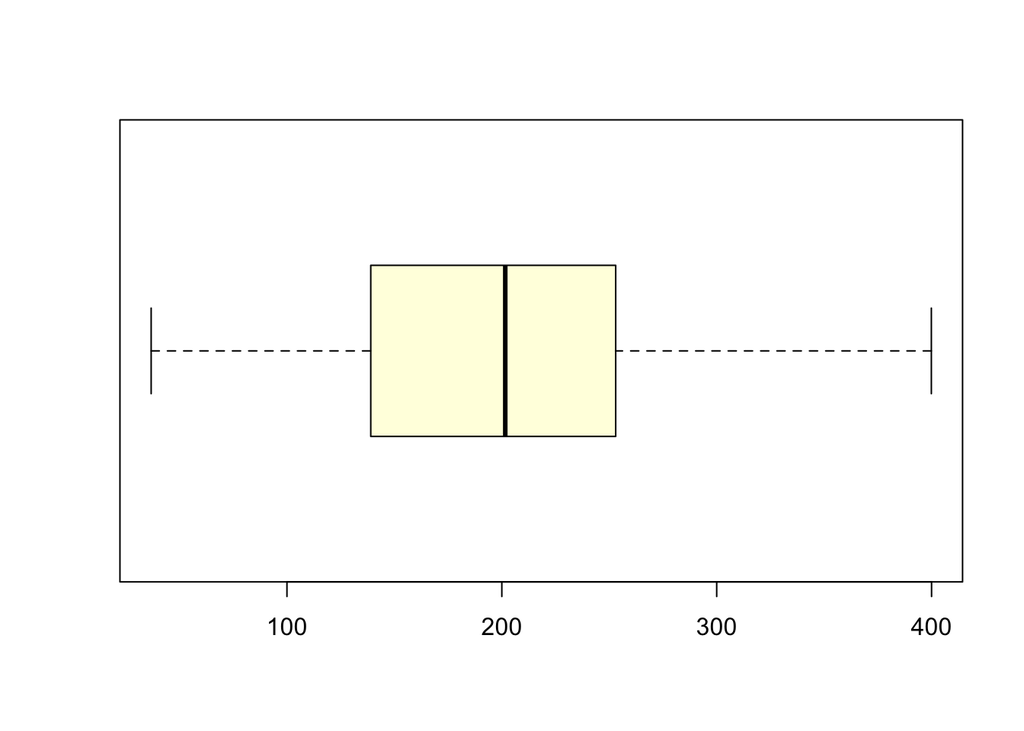

```r
don2<-don[don$con_m2<400,]
boxplot(don2$con_m2, col="lightyellow",horizontal = T)
```

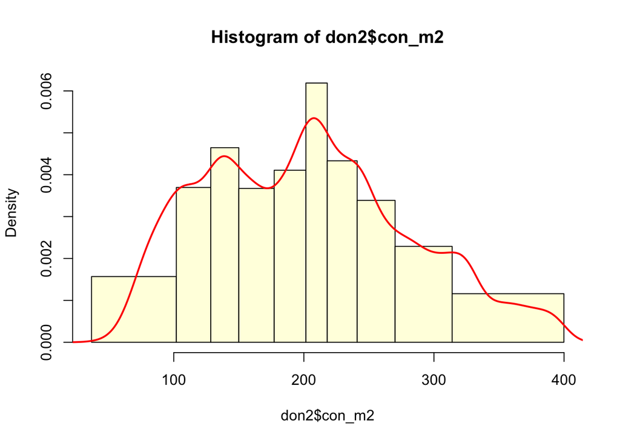

```r
hist(don2$con_m2,
     breaks = quantile(don2$con_m2,probs = seq(0,1,0.1)),
     col="lightyellow",
     probability = TRUE)
lines(density(don2$con_m2),
      col="red",
      lwd=2)
```

### Solution n°2 : Transformation logarithmique

Si on veut garder toutes les valeurs, on peut aussi passer en logarithme la variable

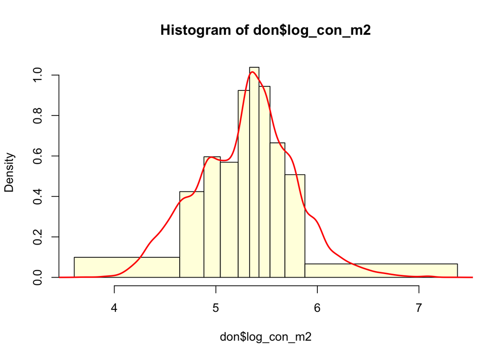

```r
don$log_con_m2<-log(don$con_m2)
hist(don$log_con_m2,
     breaks = quantile(don$log_con_m2,probs = seq(0,1,0.1)),
     col="lightyellow",
     probability = TRUE)
lines(density(don$log_con_m2),
      col="red",
      lwd=2)
```

La distribution devient unimodale et symétrique.

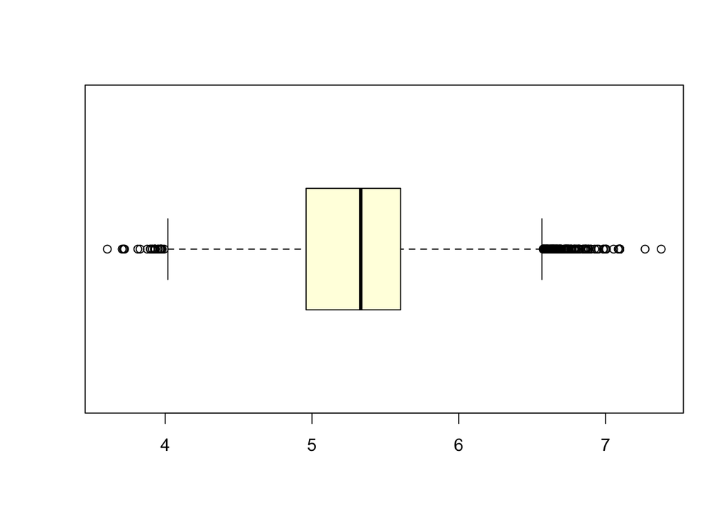

```r
boxplot(don$log_con_m2, col="lightyellow",horizontal = T)
```

Mais elle comporte toujours des valeurs exceptionnelles aux deux extrémités de la distribution cette-fois-ci.

### Discussion : quelle solution est préférable ?

- **Solution n°1** : elle a l’avantage d’aboutir à une distribution sans valeurs exceptionnelles. Mais elle retire de l’analyse les passoires énergétiques ce qui est évidemment dommage …
- **Solution n°2** : elle a l’avantage de conserver toutes les valeurs. Mais elle comporte toujours des valeurs excpetionnelles. Et elle aboutira à des modèles plus compliqués à interpréter.

On va retenir dans ce cours la solution n°1 qui est plus simple pour des débutants …

## (C) REGRESSION LINEAIRE I : INTENSITE ENERGETIQUE ET SURFACE

Y-a-t-il une relation entre la surface du logement et l’intensité ? En d’autres termes les grands logements ont-ils la même intensité energétique que les petits.

### Diagramme

On fait le graphique

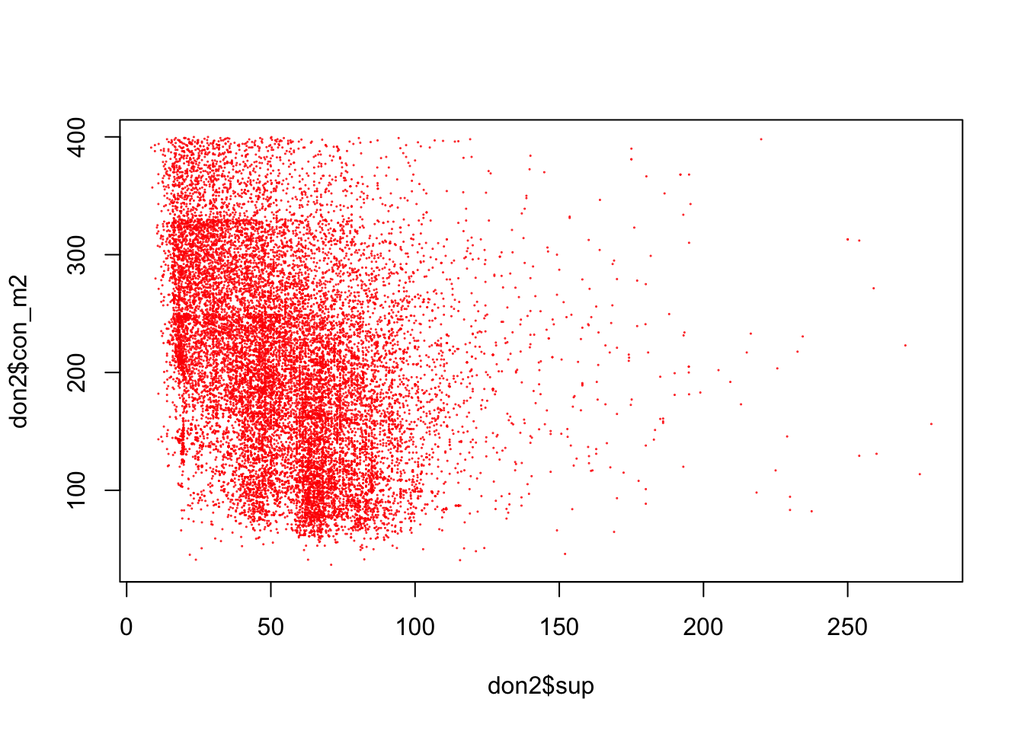

```r
plot(don2$sup,don2$con_m2, pch=20, cex=0.1, col="red")
```

### Corrélation

Puis on teste le coefficient de Pearson et celui de Sperman

```r
cor.test(don2$sup,don2$con_m2)
```

```
    Pearson's product-moment correlation

data:  don2$sup and don2$con_m2
t = -43.879, df = 21447, p-value < 2.2e-16
alternative hypothesis: true correlation is not equal to 0
95 percent confidence interval:
 -0.2992517 -0.2746906
sample estimates:
       cor
-0.2870183
```

```r
cor.test(don2$sup,don2$con_m2, method="spearman")
```

```
    Spearman's rank correlation rho

data:  don2$sup and don2$con_m2
S = 2.2012e+12, p-value < 2.2e-16
alternative hypothesis: true rho is not equal to 0
sample estimates:
       rho
-0.3384045
```

### Régression

On calcule le modèle de régression

```r
mareg<-lm(don2$con_m2~don2$sup)
summary(mareg)
```

```
Call:
lm(formula = don2$con_m2 ~ don2$sup)

Residuals:
    Min      1Q  Median      3Q     Max
-187.52  -60.25   -3.97   49.52  337.69

Coefficients:
             Estimate Std. Error t value Pr(>|t|)
(Intercept) 249.22921    1.18277  210.72   <2e-16 ***
don2$sup     -0.85874    0.01957  -43.88   <2e-16 ***
---
Signif. codes:  0 '***' 0.001 '**' 0.01 '*' 0.05 '.' 0.1 ' ' 1

Residual standard error: 74.78 on 21447 degrees of freedom
Multiple R-squared:  0.08238,   Adjusted R-squared:  0.08234
F-statistic:  1925 on 1 and 21447 DF,  p-value: < 2.2e-16
```

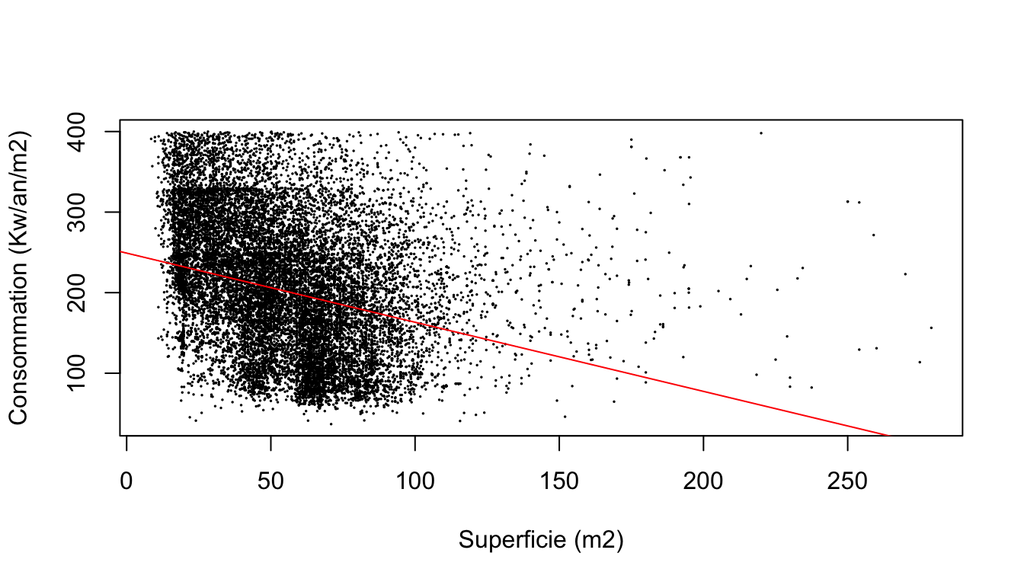

```r
plot(don2$sup,don2$con_m2, xlab="Superficie (m2)",ylab = "Consommation (Kw/an/m2)",pch=19,cex=0.1)
abline(mareg,col="red",lwd=1)
```

## (D) REGRESSION LINEAIRE II : INTENSITE ENERGETIQUE ET ANCIENNETE

Y-a-t-il une relation entre la surface du logement et l’ancienneté du logement ? En d’autres termes les logements anciens ont-ils la même intensité energétique que les logements récents

### Diagramme

On fait le graphique

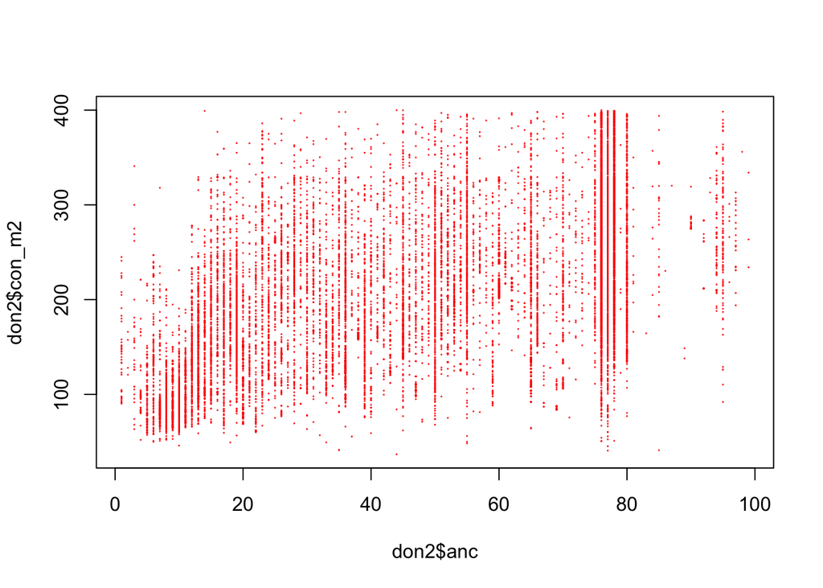

```r
plot(don2$anc,don2$con_m2, pch=20, cex=0.1, col="red")
```

### Corrélation

Puis on teste le coefficient de Pearson et celui de Sperman

```r
cor.test(don2$anc,don2$con_m2)
```

```
    Pearson's product-moment correlation

data:  don2$anc and don2$con_m2
t = 98.783, df = 21447, p-value < 2.2e-16
alternative hypothesis: true correlation is not equal to 0
95 percent confidence interval:
 0.5499354 0.5683323
sample estimates:
      cor
0.5592027
```

```r
cor.test(don2$anc,don2$con_m2, method="spearman")
```

```
    Spearman's rank correlation rho

data:  don2$anc and don2$con_m2
S = 7.0097e+11, p-value < 2.2e-16
alternative hypothesis: true rho is not equal to 0
sample estimates:
      rho
0.5737865
```

### Régression

On calcule le modèle de régression

```r
mareg2<-lm(don2$con_m2~don2$anc)
summary(mareg2)
```

```
Call:
lm(formula = don2$con_m2 ~ don2$anc)

Residuals:
     Min       1Q   Median       3Q      Max
-225.703  -46.868   -8.016   42.810  251.851

Coefficients:
             Estimate Std. Error t value Pr(>|t|)
(Intercept) 123.67433    0.91141  135.69   <2e-16 ***
don2$anc      1.68387    0.01705   98.78   <2e-16 ***
---
Signif. codes:  0 '***' 0.001 '**' 0.01 '*' 0.05 '.' 0.1 ' ' 1

Residual standard error: 64.72 on 21447 degrees of freedom
Multiple R-squared:  0.3127,    Adjusted R-squared:  0.3127
F-statistic:  9758 on 1 and 21447 DF,  p-value: < 2.2e-16
```

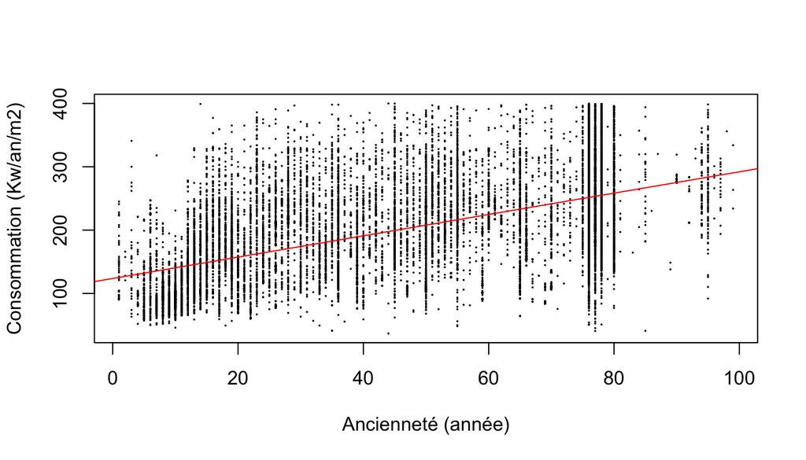

```r
plot(don2$anc,don2$con_m2, xlab="Ancienneté (année)",ylab = "Consommation (Kw/an/m2)",pch=19,cex=0.1)
abline(mareg2,col="red",lwd=1)
```

## (E) REGRESSION LINEAIRE III : EFFET COMBINE DES DEUX VARIABLES EXPLICATIVES

On peut combiner les deux effets dans un même modèle.

```r
mareg3<-lm(don2$con_m2~don2$sup+don2$anc)
summary(mareg3)
```

```
Call:
lm(formula = don2$con_m2 ~ don2$sup + don2$anc)

Residuals:
     Min       1Q   Median       3Q      Max
-246.127  -43.735   -4.392   38.747  266.920

Coefficients:
             Estimate Std. Error t value Pr(>|t|)
(Intercept) 166.51583    1.28168  129.92   <2e-16 ***
don2$sup     -0.73850    0.01622  -45.53   <2e-16 ***
don2$anc      1.62864    0.01632   99.78   <2e-16 ***
---
Signif. codes:  0 '***' 0.001 '**' 0.01 '*' 0.05 '.' 0.1 ' ' 1

Residual standard error: 61.8 on 21446 degrees of freedom
Multiple R-squared:  0.3733,    Adjusted R-squared:  0.3732
F-statistic:  6387 on 2 and 21446 DF,  p-value: < 2.2e-16
```

On remarque que les coefficients changent légèrement mais les deux variables explicatives demeurent significatives. Le modèle final explique 37% de la variance des consommations énergétiques.

## (F) TEST D’EGALITE DES MOYENNES : INTENSITE ENERGETIQUE ET TYPE DE LOGEMENT

### Hypothèses

On considère une variable **Y quantitative continue** définie sur une population de réféence P et une variable **X qualitative à deux modalités** divisant P en deux sous population P1 et P2.

Soit par exemple la variable Y = con_m2 et la variable X = typ. On peut se demander si les maisons ont une intensité énergétique supérieure à celle des appartements.

```r
Y<-don2$con_m2
nomY <-"Consommation énergétique en kW/an/m2"

X<-don2$typ
nomX <- "Type de logement"
```

### Visualisations

Le plus simple est d’utiliser **boxplot()** en version de base …

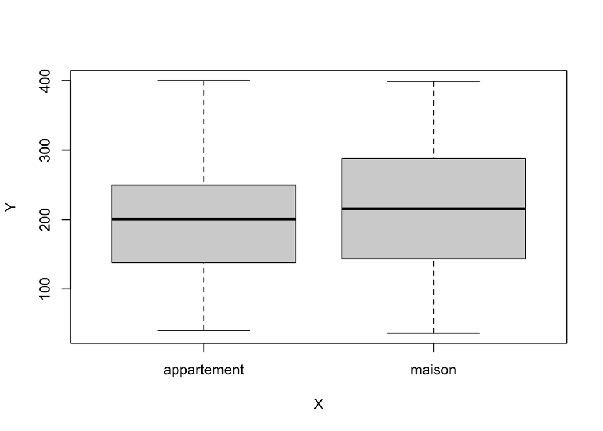

```r
boxplot(Y~X)
```

… ou améliorée

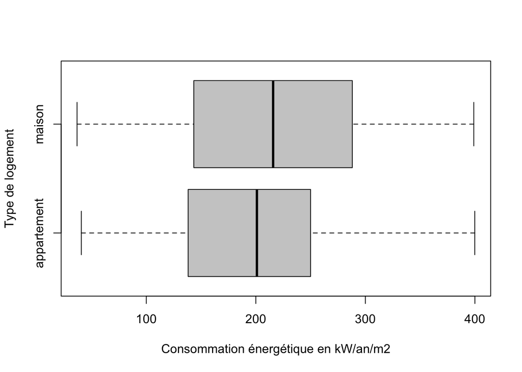

```r
boxplot(Y~X,horizontal=T, xlab = nomY, ylab=nomX, col="gray80")
```

On peut aussi utiliser le package **beanplot()** en version simple …

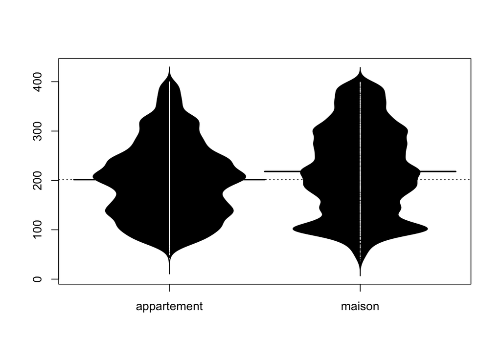

```r
library(beanplot)
beanplot(Y~X,ll = 0)
```

… ou améliorée :

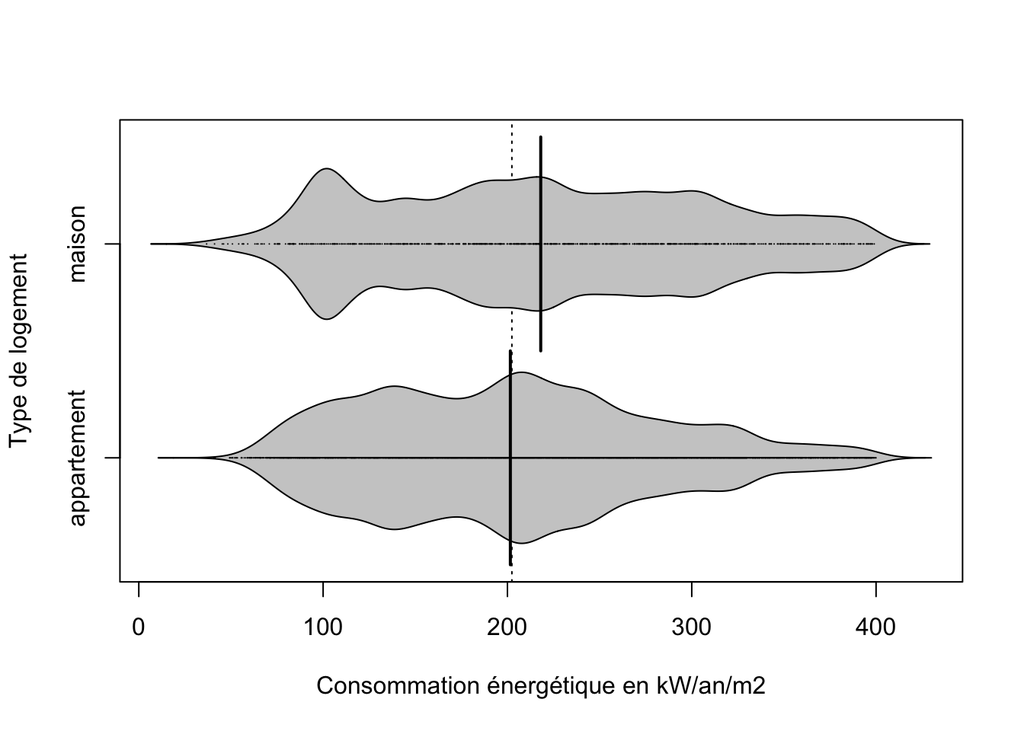

```r
library(beanplot)
beanplot(Y~X,horizontal=T, xlab = nomY, ylab=nomX,col = "gray80",ll=0)
```

### Paramètres principaux

On détermine la moyenne et l’écart-type de chaque échantillon avec la fonction tapply() couplée avec les fonctions mean(), sd() ou summary()

```r
tapply(Y,X, mean)
```

```
appartement      maison
   201.5849    218.0653
```

```r
tapply(Y,X,sd)
```

```
appartement      maison
   77.37425    88.68721
```

```r
tapply(Y,X, summary)
```

```
$appartement
   Min. 1st Qu.  Median    Mean 3rd Qu.    Max.
   40.7   138.2   201.0   201.6   250.0   399.9

$maison
   Min. 1st Qu.  Median    Mean 3rd Qu.    Max.
   36.8   143.4   215.8   218.1   288.1   399.0
```

### Test d’égalité des moyennes

Si la distribution est gaussienne on utilise le test de Student :

```r
t.test(Y~X)
```

```
    Welch Two Sample t-test

data:  Y by X
t = -5.9899, df = 1168.9, p-value = 2.791e-09
alternative hypothesis: true difference in means between group appartement and group maison is not equal to 0
95 percent confidence interval:
 -21.87859 -11.08227
sample estimates:
mean in group appartement      mean in group maison
                 201.5849                  218.0653
```

Si ce n’est pas le cas et s’il y a des valeurs exceptionnelles on préfèrera le test de Wilcoxon basé sur les rangs des valeurs (comme le coefficient de corrélation de Spearman)

```r
wilcox.test(Y~X)
```

```
    Wilcoxon rank sum test with continuity correction

data:  Y by X
W = 9859545, p-value = 6.89e-09
alternative hypothesis: true location shift is not equal to 0
```

### Conclusion

Les deux tests sont significatifs et on peut conclure sans risque d’erreur que les maisons sont plus énergivores que les appartements. Plus précisément elles ont une consommation supérieure en moyenne de 16 kW/an/m2 avec unintervalle de confiance compris entre 11 et 21 kW/an/m2

## (G) ANALYSE DE VARIANCE I : INTENSITE ENERGETIQUE ET PERIODE DE CONSTRUCTION

### Hypothèses

On considère une variable **Y quantitative continue** définie sur une population de réféence P et une variable **X qualitative à k modalités** divisant P en k sous population P1…Pk.

Soit par exemple la variable Y = con_m2 et la variable X = Période de construction. X ressemble à la variable ancienneté mais elle est exprimée sous forme qualitative

```r
table(don2$per)
```

```
avant 1948  1948-1974  1975-1977  1978-1982  1983-1988  1989-2000  2001-2005
      2740       7900        706        720        798       2497       1093
 2006-2012  2013-2021 après 2021
      2147       2755         93
```

### Calcul des paramètres principaux

tapply(*variable à analyser, variable de partition , function*)

La fonction **tapply()** s’applique sur les tableaux (*data.frame*). Il y a des fonctions équvalentes pour les listes, les matrices, etc…

```r
moy<-tapply(X = don2$con_m2, INDEX = don2$per, FUN = mean)
moy
```

```
avant 1948  1948-1974  1975-1977  1978-1982  1983-1988  1989-2000  2001-2005
  265.8024   230.3255   202.1351   199.2268   190.0982   192.6435   169.7159
 2006-2012  2013-2021 après 2021
  167.0632   115.3379   138.9204
```

```r
ect<-tapply(don2$con_m2, don2$per, sd)
ect
```

```
avant 1948  1948-1974  1975-1977  1978-1982  1983-1988  1989-2000  2001-2005
  70.50660   68.26232   70.39653   71.41809   60.90544   63.73097   71.32502
 2006-2012  2013-2021 après 2021
  55.43260   42.58044   50.88078
```

```r
100*ect/moy
```

```
avant 1948  1948-1974  1975-1977  1978-1982  1983-1988  1989-2000  2001-2005
  26.52595   29.63733   34.82647   35.84763   32.03893   33.08235   42.02612
 2006-2012  2013-2021 après 2021
  33.18062   36.91798   36.62585
```

```r
tapply(don2$con_m2, don2$per, summary)
```

```
$`avant 1948`
   Min. 1st Qu.  Median    Mean 3rd Qu.    Max.
   41.1   213.0   270.1   265.8   318.7   399.0

$`1948-1974`
   Min. 1st Qu.  Median    Mean 3rd Qu.    Max.
   40.7   188.5   223.0   230.3   273.0   399.9

$`1975-1977`
   Min. 1st Qu.  Median    Mean 3rd Qu.    Max.
   68.0   135.2   210.8   202.1   240.2   389.0

$`1978-1982`
   Min. 1st Qu.  Median    Mean 3rd Qu.    Max.
   36.8   143.2   182.4   199.2   242.9   399.9

$`1983-1988`
   Min. 1st Qu.  Median    Mean 3rd Qu.    Max.
   55.6   158.0   171.0   190.1   228.7   385.0

$`1989-2000`
   Min. 1st Qu.  Median    Mean 3rd Qu.    Max.
   41.1   138.0   192.0   192.6   236.0   398.0

$`2001-2005`
   Min. 1st Qu.  Median    Mean 3rd Qu.    Max.
   60.0   120.0   148.3   169.7   210.0   386.0

$`2006-2012`
   Min. 1st Qu.  Median    Mean 3rd Qu.    Max.
   49.3   124.1   163.0   167.1   199.0   399.1

$`2013-2021`
   Min. 1st Qu.  Median    Mean 3rd Qu.    Max.
   46.0    86.0   102.0   115.3   135.0   340.9

$`après 2021`
   Min. 1st Qu.  Median    Mean 3rd Qu.    Max.
   63.3    97.6   131.8   138.9   162.0   300.0
```

### Visualisation

On utilise comme précédemment boxplot() :

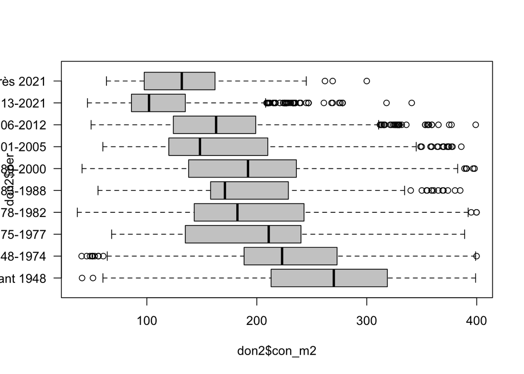

```r
boxplot(don2$con_m2~don2$per, col="gray80",horizontal=T,las=T)
```

Ou bien beanplot() :

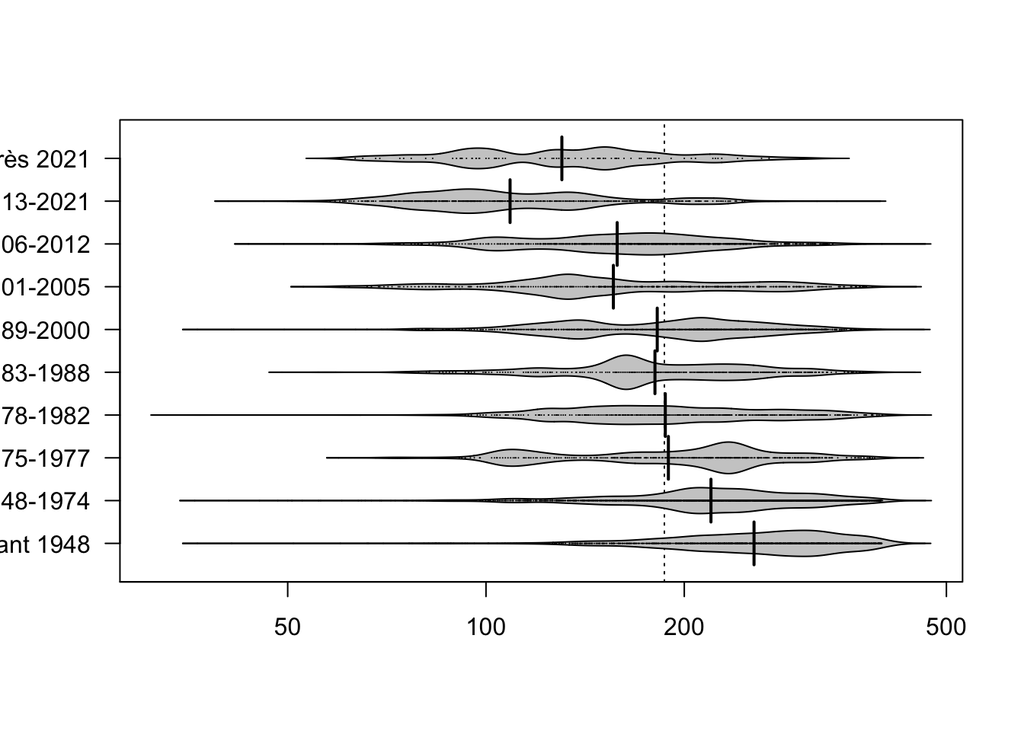

```r
library(beanplot)
beanplot(don2$con_m2~don2$per,col = "gray80", horizontal = T, ll=0,las=T)
```

### Modélisation simple

La solution la plus simple est d’utiliser la fonction **lm()** que l’on a déjà vu pour la régression.

```r
modaov1<-lm(don2$con_m2~don2$per)
summary(modaov1)
```

```
Call:
lm(formula = don2$con_m2 ~ don2$per)

Residuals:
     Min       1Q   Median       3Q      Max
-224.702  -42.325   -7.325   38.198  232.037

Coefficients:
                   Estimate Std. Error t value Pr(>|t|)
(Intercept)         265.802      1.224  217.09   <2e-16 ***
don2$per1948-1974   -35.477      1.421  -24.97   <2e-16 ***
don2$per1975-1977   -63.667      2.705  -23.54   <2e-16 ***
don2$per1978-1982   -66.576      2.684  -24.80   <2e-16 ***
don2$per1983-1988   -75.704      2.578  -29.36   <2e-16 ***
don2$per1989-2000   -73.159      1.773  -41.26   <2e-16 ***
don2$per2001-2005   -96.086      2.293  -41.91   <2e-16 ***
don2$per2006-2012   -98.739      1.847  -53.45   <2e-16 ***
don2$per2013-2021  -150.464      1.729  -87.02   <2e-16 ***
don2$peraprès 2021 -126.882      6.758  -18.78   <2e-16 ***
---
Signif. codes:  0 '***' 0.001 '**' 0.01 '*' 0.05 '.' 0.1 ' ' 1

Residual standard error: 64.09 on 21439 degrees of freedom
Multiple R-squared:  0.3263,    Adjusted R-squared:  0.326
F-statistic:  1154 on 9 and 21439 DF,  p-value: < 2.2e-16
```

On peut ensuite appliquer une analyse de variance avec **anova()** sur le modèle pour mesurer la variance totale et la variance résiduelle ainsi que la significativité de la relation.

```r
anova(modaov1)
```

```
Analysis of Variance Table

Response: don2$con_m2
             Df   Sum Sq Mean Sq F value    Pr(>F)
don2$per      9 42646498 4738500  1153.6 < 2.2e-16 ***
Residuals 21439 88059604    4107
---
Signif. codes:  0 '***' 0.001 '**' 0.01 '*' 0.05 '.' 0.1 ' ' 1
```

## (G) ANALYSE DE VARIANCE II : INTENSITE ENERGETIQUE ET TYPE DE COMBUSTIBLE

### Hypothèses

Soit par exemple la variable Y = con_m2 et la variable X = ene qui est le type de combustible. On examine les modalités de X

```r
table(don2$ene)
```

```
                                               Bois – Bûches
                                                           7
                     Bois – Granulés (pellets) ou briquettes
                                                           4
                               Bois – Plaquettes forestières
                                                           1
                                                     Charbon
                                                           0
                                                 Électricité
                                                        7934
Électricité d'origine renouvelable utilisée dans le bâtiment
                                                           0
                                            Fioul domestique
                                                         175
                                                 Gaz naturel
                                                        9224
                                                         GPL
                                                          15
                                                     Propane
                                                           0
                                  Réseau de Chauffage urbain
                                                        4089
                                      Réseau de Froid Urbain
                                                           0
```

On procède à un regroupement en trois grands types

```r
don2$ene3<-don2$ene
levels(don2$ene3) <- c( "Hydrocarbures"   ,
 "Hydrocarbures"      ,
 "Hydrocarbures"       ,
 "Hydrocarbures"        ,
 "Électricité"      ,
 "Électricité",
"Hydrocarbures"     ,
"Hydrocarbures"         ,
"Hydrocarbures"          ,
"Hydrocarbures"           ,
 "Réseau urbain"             ,
 "Réseau urbain" )
table(don2$ene3)
```

```
Hydrocarbures   Électricité Réseau urbain
         9426          7934          4089
```

### Calcul des paramètres principaux

tapply(*variable à analyser, variable de partition , function*)

La fonction **tapply()** s’applique sur les tableaux (*data.frame*). Il y a des fonctions équvalentes pour les listes, les matrices, etc…

```r
moy<-tapply(X = don2$con_m2, INDEX = don2$ene3, FUN = mean)
moy
```

```
Hydrocarbures   Électricité Réseau urbain
     179.2787      239.9257      182.9685
```

```r
ect<-tapply(don2$con_m2, don2$ene3, sd)
ect
```

```
Hydrocarbures   Électricité Réseau urbain
     79.11874      72.22939      55.44041
```

```r
100*ect/moy
```

```
Hydrocarbures   Électricité Réseau urbain
     44.13171      30.10490      30.30052
```

```r
tapply(don2$con_m2, don2$ene3, summary)
```

```
$Hydrocarbures
   Min. 1st Qu.  Median    Mean 3rd Qu.    Max.
   50.0   114.0   162.0   179.3   235.0   399.9

$Électricité
   Min. 1st Qu.  Median    Mean 3rd Qu.    Max.
   36.8   189.8   234.3   239.9   294.0   399.8

$`Réseau urbain`
   Min. 1st Qu.  Median    Mean 3rd Qu.    Max.
   57.2   138.0   190.0   183.0   221.0   398.0
```

### Visualisation

On utilise comme précédemment boxplot() :

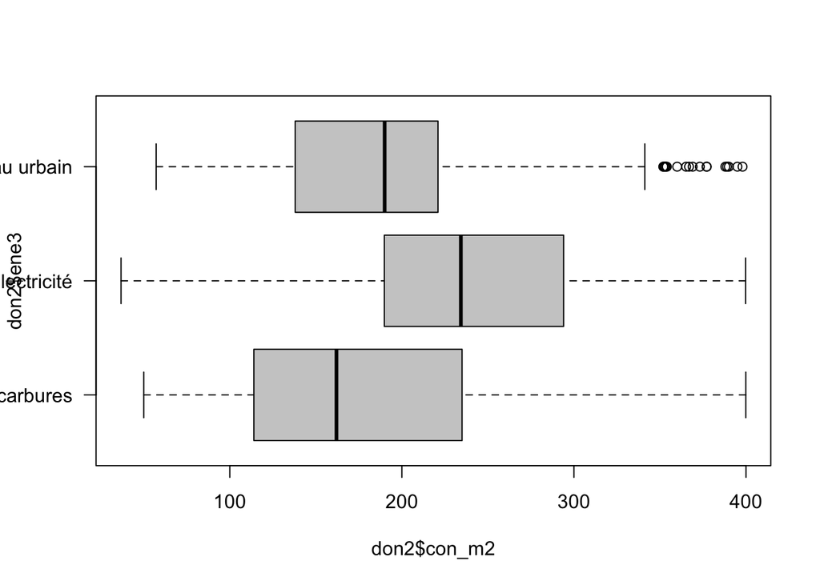

```r
boxplot(don2$con_m2~don2$ene3, col="gray80",horizontal=T,las=T)
```

Ou bien beanplot() :

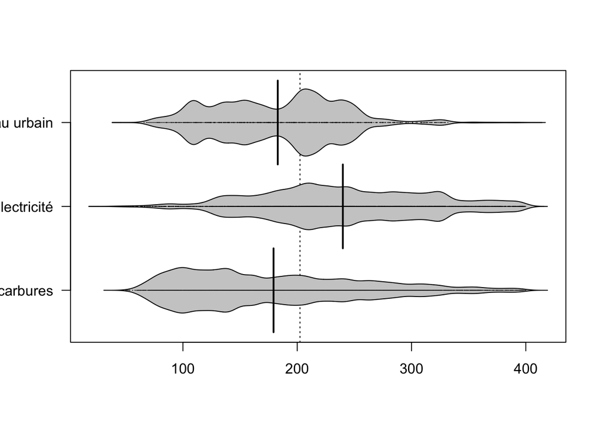

```r
library(beanplot)
beanplot(don2$con_m2~don2$ene3,col = "gray80", horizontal = T, ll=0,las=T)
```

### Modélisation simple

La solution la plus simple est d’utiliser la fonction **lm()** que l’on a déjà vu pour la régression.

```r
modaov2<-lm(don2$con_m2~don2$ene3)
summary(modaov2)
```

```
Call:
lm(formula = don2$con_m2 ~ don2$ene3)

Residuals:
     Min       1Q   Median       3Q      Max
-203.126  -56.279   -7.926   50.074  220.621

Coefficients:
                       Estimate Std. Error t value Pr(>|t|)
(Intercept)            179.2787     0.7475 239.840  < 2e-16 ***
don2$ene3Électricité    60.6471     1.1057  54.850  < 2e-16 ***
don2$ene3Réseau urbain   3.6898     1.3590   2.715  0.00663 **
---
Signif. codes:  0 '***' 0.001 '**' 0.01 '*' 0.05 '.' 0.1 ' ' 1

Residual standard error: 72.57 on 21446 degrees of freedom
Multiple R-squared:  0.1358,    Adjusted R-squared:  0.1358
F-statistic:  1686 on 2 and 21446 DF,  p-value: < 2.2e-16
```

On peut ensuite appliquer une analyse de variance avec **anova()** sur le modèle pour mesurer la variance totale et la variance résiduelle ainsi que la significativité de la relation.

```r
anova(modaov2)
```

```
Analysis of Variance Table

Response: don2$con_m2
             Df    Sum Sq Mean Sq F value    Pr(>F)
don2$ene3     2  17755552 8877776  1685.6 < 2.2e-16 ***
Residuals 21446 112950551    5267
---
Signif. codes:  0 '***' 0.001 '**' 0.01 '*' 0.05 '.' 0.1 ' ' 1
```

## (H) MODELE FINAL

### Régression

On reprend toutes nos variables explicatives qualitatives ou quantitatives dans un seul modèle mais en retirant l’ancienneté puisque l’on a mis les périodes de temps

```r
modfin<-lm(don2$con_m2~don2$sup +  don2$typ + don2$per + don2$ene3)
summary(modfin)
```

```
Call:
lm(formula = don2$con_m2 ~ don2$sup + don2$typ + don2$per + don2$ene3)

Residuals:
     Min       1Q   Median       3Q      Max
-269.862  -36.047   -3.999   34.508  254.268

Coefficients:
                         Estimate Std. Error t value Pr(>|t|)
(Intercept)             261.65504    1.60537 162.987  < 2e-16 ***
don2$sup                 -0.53601    0.01716 -31.234  < 2e-16 ***
don2$typmaison           19.84701    1.92318  10.320  < 2e-16 ***
don2$per1948-1974        -8.23909    1.34481  -6.127 9.13e-10 ***
don2$per1975-1977       -32.43478    2.45338 -13.220  < 2e-16 ***
don2$per1978-1982       -38.56327    2.42856 -15.879  < 2e-16 ***
don2$per1983-1988       -51.92201    2.32383 -22.343  < 2e-16 ***
don2$per1989-2000       -65.46102    1.59318 -41.088  < 2e-16 ***
don2$per2001-2005       -84.25043    2.05578 -40.982  < 2e-16 ***
don2$per2006-2012       -77.46402    1.68190 -46.057  < 2e-16 ***
don2$per2013-2021      -125.23552    1.58804 -78.862  < 2e-16 ***
don2$peraprès 2021     -133.51840    6.01536 -22.196  < 2e-16 ***
don2$ene3Électricité     42.32463    0.95146  44.484  < 2e-16 ***
don2$ene3Réseau urbain  -15.81124    1.13186 -13.969  < 2e-16 ***
---
Signif. codes:  0 '***' 0.001 '**' 0.01 '*' 0.05 '.' 0.1 ' ' 1

Residual standard error: 57.02 on 21435 degrees of freedom
Multiple R-squared:  0.4668,    Adjusted R-squared:  0.4665
F-statistic:  1444 on 13 and 21435 DF,  p-value: < 2.2e-16
```

```r
anova(modfin)
```

```
Analysis of Variance Table

Response: don2$con_m2
             Df   Sum Sq  Mean Sq F value    Pr(>F)
don2$sup      1 10767507 10767507 3311.97 < 2.2e-16 ***
don2$typ      1  2560976  2560976  787.73 < 2.2e-16 ***
don2$per      9 38779283  4308809 1325.34 < 2.2e-16 ***
don2$ene3     2  8911312  4455656 1370.51 < 2.2e-16 ***
Residuals 21435 69687024     3251
---
Signif. codes:  0 '***' 0.001 '**' 0.01 '*' 0.05 '.' 0.1 ' ' 1
```

Toutes les variables sont significatives et le modèle résumé 47% de la variance totale. On peut résumernos découvertes comme suit :

**Toutes choses égales quant aux autre variables …**

- **sup** : l’intensité énergétique diminue de 0.5 kW/an/m2 chaque fois que la surface du logement augmente de 1 m2
- **typ** : les maisons ont une consommation supérieure à celle des appartements d’environ 20 kW/an/m2
- **per** : l’intensité varie d’une période à l’autre, globalement dans le sens d’une diminution au cours du temps, exception faite de la période 2006-12.
- **ene3** : les logements chauffés à l’électricité sont les plus energivores et les logements raccordés au chauffage urbain les moins énergivores.

### Calcul des résidus

On peut ajouter à notre tableau des logements la consommation théorique (con_m2_EST) déduite du modèle et la consommation résiduelle (con_m2_RES).

```r
don2$con_m2_EST <-modfin$fitted.values
don2$con_m2_RES <- modfin$residuals
```

On peut alors examiner les logements qui s’écartent le plus des prédictions du modèle positivement ou négativement.

```r
don2 <- don2 %>% arrange(con_m2_RES)
kable(head(don2,10))
```

| iris_code | iris_name | dpe | con_tot | sup | con_m2 | typ | ene | anc | per | ene3 | con_m2_EST | con_m2_RES |
| --- | --- | --- | --- | --- | --- | --- | --- | --- | --- | --- | --- | --- |
| 765400502 | Gare SNCF | E | 986.9 | 24.0 | 41.1 | maison | Électricité | 85 | avant 1948 | Électricité | 310.9623 | -269.8623 |
| 765400502 | Gare SNCF | E | 993.3 | 21.9 | 45.3 | maison | Électricité | 77 | 1948-1974 | Électricité | 303.8489 | -258.5489 |
| 765400203 | Croix de Pierre | E | 1319.5 | 26.0 | 50.8 | maison | Électricité | 76 | 1948-1974 | Électricité | 301.6512 | -250.8512 |
| 765400501 | Cauchoise Saint-Gervais Est | F | 1469.8 | 19.3 | 76.1 | maison | Électricité | 77 | 1948-1974 | Électricité | 305.2425 | -229.1425 |
| 765400106 | Beauvoisine | D | 1629.4 | 21.5 | 75.7 | maison | Électricité | 77 | 1948-1974 | Électricité | 304.0633 | -228.3633 |
| 765400901 | Grand Mare Centre | D | 3749.7 | 66.8 | 56.1 | maison | Électricité | 55 | 1948-1974 | Électricité | 279.7818 | -223.6818 |
| 765400501 | Cauchoise Saint-Gervais Est | D | 2107.2 | 40.0 | 52.6 | appartement | Électricité | 77 | 1948-1974 | Électricité | 274.3000 | -221.7000 |
| 765400602 | Grieu Vallon Suisse | C | 2766.2 | 46.0 | 60.1 | appartement | Électricité | 77 | avant 1948 | Électricité | 279.3230 | -219.2230 |
| 765400202 | Martainville | G | 2162.6 | 25.8 | 83.8 | maison | Électricité | 77 | 1948-1974 | Électricité | 301.7584 | -217.9584 |
| 765400102 | Vieux Marché Palais de Justice | G | 1865.9 | 21.3 | 87.4 | maison | Électricité | 77 | 1948-1974 | Électricité | 304.1705 | -216.7705 |

On trouve plusieurs cas de maisons anciennes et de petite superficie chauffées à l’électricité qui cumulent les désavantage et devraient avoir une intensité énergétique de 300 W/an/m2 selon notre modèle. Or, elles affichent une consommation beaucoup plus réduite de moins de 100 kW/an/m2. S’agit-il de logements rénovés ?

```r
don2 <- don2 %>% arrange(-con_m2_RES)
kable(head(don2,10))
```

| iris_code | iris_name | dpe | con_tot | sup | con_m2 | typ | ene | anc | per | ene3 | con_m2_EST | con_m2_RES |
| --- | --- | --- | --- | --- | --- | --- | --- | --- | --- | --- | --- | --- |
| 765400403 | Fond du Val Chasselière | F | 87668.1 | 220.0 | 398.0 | appartement | Gaz naturel | 78 | avant 1948 | Hydrocarbures | 143.7319 | 254.2681 |
| 765401001 | Voltaire Grammont | F | 26003.7 | 68.9 | 377.1 | appartement | Réseau de Chauffage urbain | 16 | 2006-2012 | Réseau urbain | 131.4484 | 245.6516 |
| 765400105 | Grand Pont Général Leclerc | F | 68330.5 | 175.0 | 390.0 | appartement | Gaz naturel | 78 | avant 1948 | Hydrocarbures | 167.8526 | 222.1474 |
| 765401001 | Voltaire Grammont | F | 24351.7 | 68.9 | 353.2 | appartement | Réseau de Chauffage urbain | 16 | 2006-2012 | Réseau urbain | 131.4484 | 221.7516 |
| 765401001 | Voltaire Grammont | F | 24351.7 | 68.9 | 353.2 | appartement | Réseau de Chauffage urbain | 16 | 2006-2012 | Réseau urbain | 131.4484 | 221.7516 |
| 765400105 | Grand Pont Général Leclerc | F | 66685.1 | 175.0 | 381.0 | appartement | Gaz naturel | 78 | avant 1948 | Hydrocarbures | 167.8526 | 213.1474 |
| 765400103 | Vieux Marché Saint-Patrice | F | 66051.3 | 180.2 | 366.5 | appartement | Gaz naturel | 77 | avant 1948 | Hydrocarbures | 165.0653 | 201.4347 |
| 765400306 | Orléans | F | 22232.5 | 61.0 | 364.0 | appartement | Gaz naturel | 36 | 1989-2000 | Hydrocarbures | 163.4972 | 200.5028 |
| 765401001 | Voltaire Grammont | F | 22508.5 | 67.8 | 331.8 | appartement | Réseau de Chauffage urbain | 16 | 2006-2012 | Réseau urbain | 132.0380 | 199.7620 |
| 765401001 | Voltaire Grammont | E | 22718.1 | 68.9 | 329.5 | appartement | Réseau de Chauffage urbain | 16 | 2006-2012 | Réseau urbain | 131.4484 | 198.0516 |

A l’inverse du cas précédent, on trouve ici de grands appartements, très anciens (avant 1948) ou datant de 2006-12 qui ne sont pas chauffés à l’élecricité et devrait avoir une consommation faible. Mais qui en fait sont des passoires énergétiques pour une raison qui reste à expliquer.

### Y-a-t-il un effet local ?

```r
res_iris <- don2 %>% group_by(iris_code,iris_name) %>%
                      summarise(n =n(),
                                OBS = mean(con_m2),
                                EST = mean(con_m2_EST),
                                RES = mean(con_m2_RES)) %>%
                      arrange(RES)
kable(res_iris, digits=1)
```

| iris_code | iris_name | n | OBS | EST | RES |
| --- | --- | --- | --- | --- | --- |
| 765400301 | Île Lacroix | 204 | 175.9 | 213.8 | -37.9 |
| 765400603 | Zone de la Vallée des Deux Rivières | 326 | 143.7 | 167.1 | -23.4 |
| 765400306 | Orléans | 905 | 189.9 | 211.7 | -21.8 |
| 765400602 | Grieu Vallon Suisse | 441 | 179.8 | 200.5 | -20.7 |
| 765400305 | Saint-Sever Ouest Faïenciers | 732 | 178.4 | 196.8 | -18.4 |
| 765400303 | Saint-Sever Est | 1007 | 165.5 | 180.9 | -15.3 |
| 765401003 | Saint-Clément Méridienne | 953 | 173.1 | 182.2 | -9.1 |
| 765400405 | Cauchoise Saint-Gervais Ouest | 564 | 222.8 | 228.7 | -5.9 |
| 765400203 | Croix de Pierre | 875 | 227.2 | 233.0 | -5.8 |
| 765400701 | Vieux Sapins | 201 | 162.2 | 167.4 | -5.3 |
| 765401005 | Saint-Clément Jean Rondeaux | 963 | 143.2 | 147.6 | -4.5 |
| 765400202 | Martainville | 2022 | 195.5 | 198.6 | -3.1 |
| 765400702 | Sapins | 217 | 205.7 | 207.4 | -1.7 |
| 765401002 | Trianon Jardin des Plantes | 415 | 174.5 | 175.6 | -1.1 |
| 765400106 | Beauvoisine | 643 | 250.3 | 250.4 | -0.1 |
| 765400902 | Grand Mare Périphérie | 206 | 143.7 | 142.7 | 1.0 |
| 765400102 | Vieux Marché Palais de Justice | 374 | 253.1 | 251.5 | 1.6 |
| 765401001 | Voltaire Grammont | 1080 | 163.5 | 161.5 | 2.0 |
| 765400201 | Place Saint-Marc | 532 | 237.5 | 235.2 | 2.3 |
| 765400501 | Cauchoise Saint-Gervais Est | 386 | 240.7 | 237.8 | 2.9 |
| 765400302 | Zone Gare Saint-Sever | 43 | 192.5 | 188.0 | 4.5 |
| 765400502 | Gare SNCF | 539 | 216.8 | 212.0 | 4.7 |
| 765400101 | Carmes Saint-Maclou | 430 | 259.8 | 254.9 | 4.9 |
| 765400103 | Vieux Marché Saint-Patrice | 544 | 262.3 | 257.1 | 5.1 |
| 765400404 | Pasteur Madeleine | 1316 | 211.6 | 205.9 | 5.8 |
| 765400304 | Saint-Sever Emmurées | 850 | 219.9 | 213.6 | 6.3 |
| 765400604 | Mont Gargan Saint-Paul | 382 | 195.6 | 189.2 | 6.4 |
| 765401004 | Saint-Clément Pépinières | 234 | 170.8 | 164.4 | 6.5 |
| 765400403 | Fond du Val Chasselière | 480 | 157.9 | 150.7 | 7.1 |
| 765400601 | Saint-Hilaire | 444 | 225.1 | 216.8 | 8.3 |
| 765400401 | Zone Portuaire Nord | 111 | 141.8 | 131.3 | 10.5 |
| 765400402 | Sacré-Cœur | 566 | 227.1 | 211.0 | 16.1 |
| 765400104 | Vieux Marché Sud Saint-Éloi | 393 | 250.4 | 231.8 | 18.6 |
| 765400204 | Saint-Nicaise | 480 | 248.0 | 228.4 | 19.6 |
| 765400504 | Jouvenet Est Boulingrin | 170 | 245.1 | 223.2 | 21.9 |
| 765400901 | Grand Mare Centre | 437 | 223.7 | 200.3 | 23.4 |
| 765400801 | Châtelet | 371 | 191.1 | 167.5 | 23.6 |
| 765400105 | Grand Pont Général Leclerc | 420 | 240.8 | 215.9 | 24.9 |
| 765400503 | Jouvenet Ouest Rue d’Ernemont | 191 | 250.8 | 222.6 | 28.2 |
| 765401006 | Zone Portuaire Sud | 2 | 311.4 | 258.5 | 52.9 |

Si notre modèle est correct, on déduit de l’analyse que certains lieux (iris) sont plus ou moins énergivores que prévu, toutes choses égales quant aux variables contrôlées. On se demandera par exemple :

- pourquoi la consommation énergétique est plus faible que prévu dans l’iris de Ile Lacroix (-38)
- pourquoi la consommation énergétique est plus forte que prévu dans l’iris Jouvenet Ouest Rue d’Ernemont (+28)

## (I) CARTOGRAPHIE DES EFFETS STRUCTURELS ET RESIDUELS

Nous terminons notre analyse par la création de trois cartes :

```r
mapiris2 <- mapiris %>% left_join(res_iris) %>% filter(n >10)
```

### Consommation observée

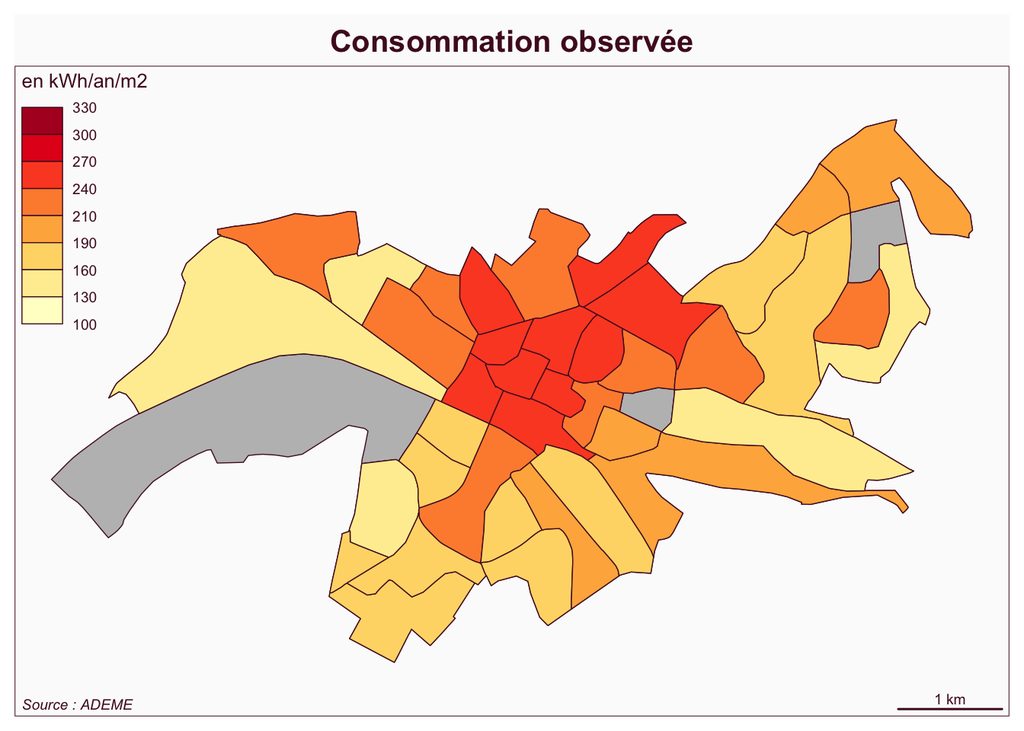

```r
mypal<-brewer.pal(8,"YlOrRd")
mybreaks <-c(100,130, 160, 190, 210, 240, 270, 300, 330)
mf_map(mapiris, type="base", col="gray")
mf_map(mapiris2,
       type = "choro",
       var = "OBS",
       pal=mypal,
       breaks = mybreaks,
       leg_title = "en kWh/an/m2",
       leg_val_rnd = 0,
       add=T)
mf_layout(title = "Consommation observée",scale = T, arrow=F, frame=T,credits = "Source : ADEME")
```

### Consommation théorique

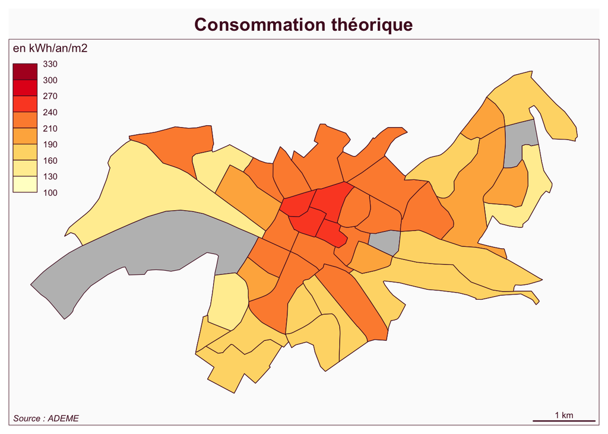

```r
mypal<-brewer.pal(8,"YlOrRd")
mybreaks <-c(100,130, 160, 190, 210, 240, 270, 300, 330)
mf_map(mapiris, type="base", col="gray")
mf_map(mapiris2,
       type = "choro",
       var = "EST",
       pal=mypal,
       breaks = mybreaks,
       leg_title = "en kWh/an/m2",
       leg_val_rnd = 0,
       add=T)
mf_layout(title = "Consommation théorique",scale = T, arrow=F, frame=T,credits = "Source : ADEME")
```

### Consommation résiduelle

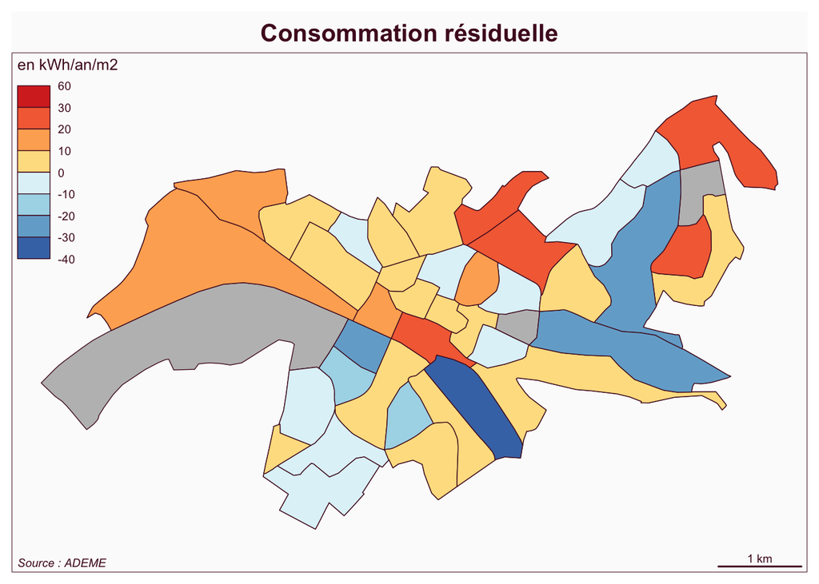

```r
mypal<-rev(brewer.pal(8,"RdYlBu"))
mybreaks <-c(-40, -30,-20, -10, 0, 10, 20, 30,60)
mf_map(mapiris, type="base", col="gray")
mf_map(mapiris2,
       type = "choro",
       var = "RES",
       pal=mypal,
       breaks = mybreaks,
       leg_title = "en kWh/an/m2",
       leg_val_rnd = 0,
       add=T )
mf_layout(title = "Consommation résiduelle",scale = T, arrow=F, frame=T,credits = "Source : ADEME")
```